# L06-2 Probability and Descriptive Statistics Continued

## Assignment Instructions

Rename with your name in place of Studentname and make your edits and updates here.

# Lesson 6: Homework / Assesment

## Objective

Acquire hands-on experience with descriptive statistics and associated plots

## Questions To Answer

1. What are the central tendencies, standard deviation, and MAD of **Lot Area**?
2. Plot histogram of **Lot Area**. What can you tell about it? Is it skewed?
3. Assuming that housing dataset is a complete population and we can use it's standard deviation as population deviation, calculate 95% confidence interval for **Lot Area** mean from 200 size sample. Output: mean, -confidence interval, +confidence interval.
4. Plot normalized scatterplot **Lot Area** and **SalePrice**
5. What is correlation coefficient for **Lot Area** and **SalePrice**?

Tips:

1. Remember to include required libraries and missing stat. functions from the lab.
2. Enclosing the expression in () will output the value of the expression. Example: (x <- 1) will output 1.

## Initial Setup

```r
# Display directory contents. This directory should contain the data for this exercise: AmesHousing.xls
dir()
```

1. 'AmesHousing.xls'

2. 'AmesHousingDataDictionary.txt'

3. 'AmesHousingWithStats.xlsx'

4. 'Bayes.xlsx'

5. 'Roger_Andre-L06-1-Lab-Center-Deviation-Histogram-Probability.ipynb'

6. 'Roger_Andre-L06-2-HW-Probability-Descriptive-Statistics.ipynb'

```r
# R doesn't have a method to calculate mode statistic - create
stat_mode <- function(x, na_rm = FALSE) {
  if(na_rm){
            x = x[!is.na(x)]
          }
  ux <- unique(x)
  return(ux[which.max(tabulate(match(x, ux)))])
}


# R doesn't have a method to calculate deviation around mean - create
avgAD <- function(x, na_rm = FALSE)
{
  if(na_rm){
    x = x[!is.na(x)]
  }
  return(sum(abs(mean(x)-x))/length(x))
}
```

```r
#Install packages if not already installed
library(readxl)
library(tidyverse)
library(corrgram)
library(caret)
```

```r
#load data

AmesHousing<-readxl::read_excel("AmesHousing.xls")
```

Hint: `Lot Area` is two words.

```r
# Question 1:
#central tendencies
mean(AmesHousing$"Lot Area")
stat_mode(AmesHousing$"Lot Area")

#standard deviation
#(sd <- ___(___))
sd(AmesHousing$"Lot Area")

#MAD
meanAD <- avgAD(AmesHousing$"Lot Area")
```

10147.9218430034

9600

7880.01775943909

## 2. Histogram Plot

Hint: Refer to Section 6.C in the Lab.

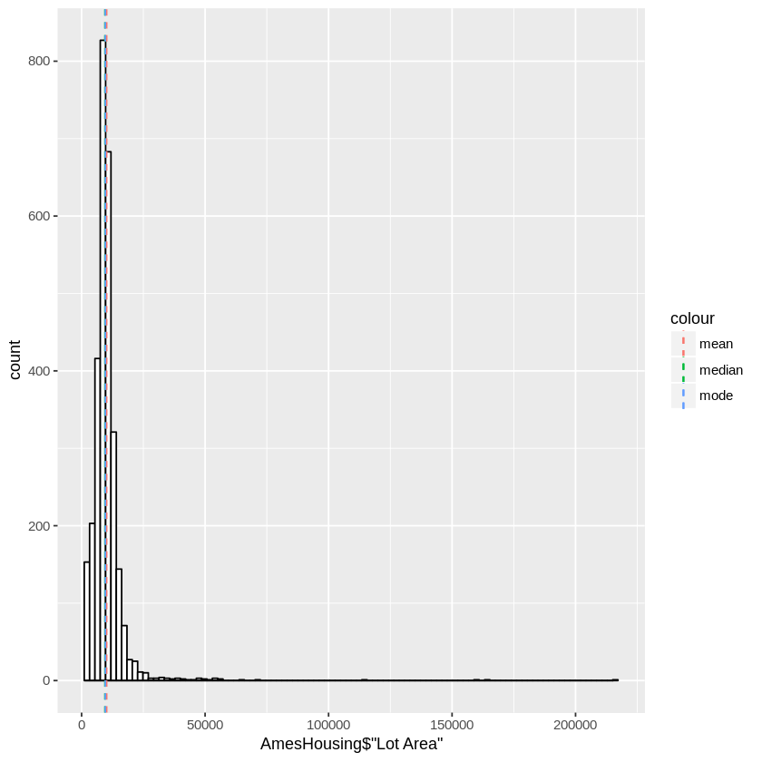

```r
#Question 2:
# Histogram of lot area overlaid with density curve
# What can you tell about it? Is it skewed?

# - Yes, it is skewed.

ggplot(AmesHousing, aes(x=AmesHousing$"Lot Area")) +
  geom_histogram(aes(y=..count..),      # Density on y-axis
                 color="black", fill="white",
                 bins = 100) +
  geom_density(alpha=.2, fill="#FF7777") + # Overlay with density plot
  geom_vline(aes(xintercept=mean(AmesHousing$"Lot Area"), color="mean"), linetype="dashed", size=.5) + #vertical line for mean
  geom_vline(aes(xintercept=median(AmesHousing$"Lot Area"), color="median"), linetype="dashed", size=.5) + #vertical line for mean
  geom_vline(aes(xintercept=stat_mode(AmesHousing$"Lot Area"), color="mode"), linetype="dashed", size=.5)  #vertical line for mode
```

Hint: Refer to Section 6.5.1 in the Lab.

```r
#Question 3:
#Assuming that housing dataset is a complete population and we can use its standard deviation as population deviation,
#calculate 95% confidence interval for **Lot Area** mean from 200 size sample.
#Output: mean, -confidence interval, +confidence interval.

sample_size <- 200
sample <- AmesHousing$"Lot Area"[sample(length(sample_size))]
mean(sample)
(mean(sample)-qnorm(0.975)*sd / sqrt(sample_size))
(mean(sample)+qnorm(0.975)*sd/sqrt(sample_size))
```

[output not shown]

31770

[output not shown]

## 4. Normalized Scatterplot

Hint: Refer to Section 6.5.2 in the Lab

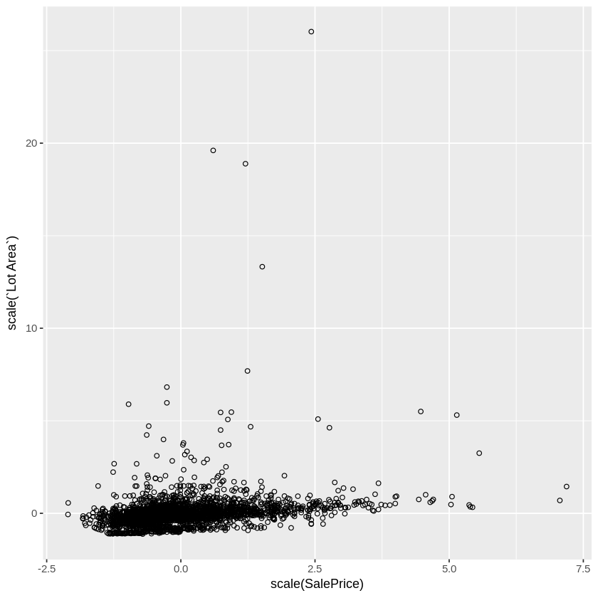

```r
#Question 4:
# Plot normalized scatterplot **Lot Area** and **SalePrice**

ggplot(AmesHousing,aes(x = scale(SalePrice), y=scale(`Lot Area`))) +
    geom_point(shape=1)
```

## 5. Correlation Matrix

Hint: Refer to Section 6.6 in the Lab

```r
#Question 5: What is correlation coefficient for **Lot Area** and **SalePrice**?
(corMatrix <- cor(na.omit(AmesHousing[, c("SalePrice", "Lot Area")])))
corMatrix[c("SalePrice"),c("Lot Area")]
```

|  | SalePrice | Lot Area |
| --- | --- | --- |
| SalePrice | 1.0000000 | 0.2665492 |
| Lot Area | 0.2665492 | 1.0000000 |

0.26654922032843